# Liste Rouge Régionale des poissons d’eau douce de Bretagne

Pré-traitements pour analyse bayésienne

OFB Bretagne

2024-08-14

# 1 Objectif : Dynamique de population des poissons d’eau douce de Bretagne

Script : 15_pre_traitements_modele_bayésien

Ce script prépare les jeux de données pour une analyse bayésienne (avec le package *popdynmodel* d’Emmanuelle Dortel).

# 2 Installation

## 2.1 Chargement des packages, fonctions et des données

```r
library(ggthemes) # Chargement des packages
library(tidyverse)
library(popdynmodel)
library(aspe)
library(aspe2)
```

```r
load(file = "../processed_data/selection_pop_ope.rda") # Chargement des données
load(file = "../processed_data/pre_traitements_donnees_env.rda")
load(file = "../processed_data/assemblage_tab_par_ope.rda")
load(file = "../processed_data/analyse_selection_especes.rda")
```

```r
rdata_tables <- misc_nom_dernier_fichier(               # Chargement des tables aspe
  repertoire = "../../../../projets/ASPE/raw_data/rdata",
  pattern = "^tables")
load(rdata_tables)

mei_table <- misc_nom_dernier_fichier(
  repertoire = "../../../../projets/ASPE/raw_data/rdata",
  pattern = "^mei")
load(mei_table)
```

# 3 Pré-traitement analyses bayésiennes

Pour réaliser l’étude bayésienne à l’aide du package *popdynmodel*, nous suivons le tutorial proposé par Emmanuelle Dortel. En amont, nous selectionnons les espèces et les stations déjà pré-sélectionnées précédemment dans l’étude. Afin de prendre un recul sur ces données, nous souhaitons représenter graphiquement les espèces et leurs fréquences d’apparitions sur les différentes stations pré-selectionnées. Dans l’idéal, il s’agit d’avoir une répartition relativement homogène des espèces, sans trop de données manquantes.

## 3.1 Visualisation et sélection des stations et des espèces

Nous sélectionnons les stations et espèces pré-sélectionnées précédemment dans l’étude.

```r
# Nous inscrivons les sta_id retenues dans nos analyses ultérieures
mes_sta_id <- c("10468", "10502", "10546", "10565",
                "10647", "10734", "10844", "10925",
                "10950", "11067", "11158", "11224",
                "11245", "11290", "11302", "11329",
                "11432", "11456", "11539", "11593",
                "11601", "11602", "11603", "11605",
                "11735", "11743", "11745", "11875",
                "11913", "12007", "12060", "12118",
                "12148", "12291", "12316", "12325",
                "12371", "12402", "12436", "12447",
                "12453", "12824", "13103")

mes_especes_lrr <- c("ANG", "LOF","CHE", "CHA", "GAR", "GOU", "VAI", "PER","TRF", "SAT", "LPP", "VAR")
```

## 3.2 Représentation des fréquences d’apparition

Nous souhaitons observer les fréquences d’apparition des espèces sur les stations sélectionnées afin de vérifier si les données ne contiennent pas une quantité trop importante de valeurs manquantes.

```r
# Création d'un dataframe avec toutes les combinaisons possibles d'années, indicateurs, stades et esp_code_alternatif
combinaisons_esp_ope <- expand.grid(annee = unique(ope_indicateur$annee),
                            indicateur = unique(ope_indicateur$indicateur),
                            stade = unique(ope_indicateur$stade),
                            esp_code_alternatif = unique(ope_indicateur$esp_code_alternatif),
                            pop_id = unique(ope_indicateur$pop_id))

# Fusionner le tableau des combinaisons avec le tableau original en ajoutant des valeurs manquantes avec valeur 0
ope_indicateur_complet <- combinaisons_esp_ope %>%
  left_join(ope_indicateur, by = c("annee", "indicateur", "stade", "esp_code_alternatif", "pop_id"))%>%
  mutate(valeur = ifelse(is.na(valeur), 0, valeur)) %>%
  select(esp_code_alternatif,
         annee,
         stade,
         indicateur,
         valeur,
         pop_id)

occur_sta_esp <- ope_indicateur_complet %>%
  filter(stade == "ind",
         indicateur == "effectif_total")
```

Nous réalisons une représentation graphique :

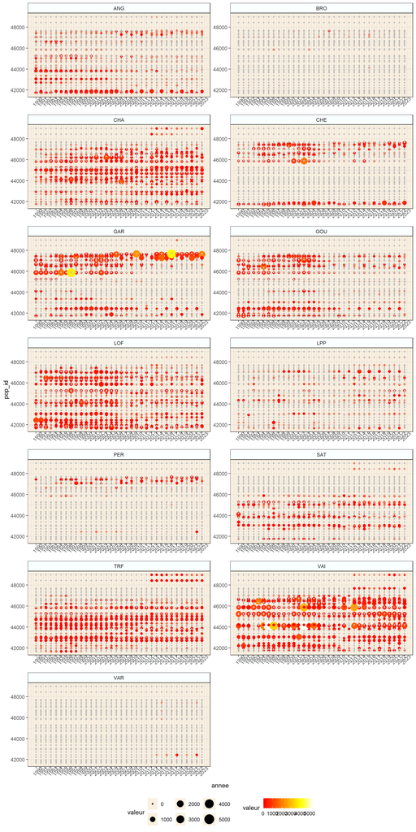

```r
# Créer le graphique avec ggplot2 et facettes pour chaque espèce
ggplot(occur_sta_esp, aes(x = annee, y = pop_id, size = valeur, color = valeur)) +
  geom_point() +
  scale_size_continuous(range = c(1, 8)) + # Ajuster la plage de taille des points selon vos préférences
  scale_color_gradientn(colors = c("grey", heat.colors(99)), na.value = "grey") + # Utiliser une palette de couleurs personnalisée
  scale_x_continuous(breaks = seq(min(occur_sta_esp$annee), max(occur_sta_esp$annee), by = 1)) +
  facet_wrap(~ esp_code_alternatif, scales = "free", ncol = 2) +
  theme_bw() +
  theme(strip.background = element_rect(color = "black", fill = "#faffff"),
        legend.position = "bottom",
        panel.background = element_rect(fill = "#faf0e0"),
        panel.grid.major = element_line(color = "lightgrey", size = 0.1),
        panel.grid.minor = element_line(color = "lightgrey"),
        axis.text.x = element_text(angle = 45))
```

# 4 Mise en place des analyses bayésiennes

Cette partie de pré-traitement suit le tuto “Tutorial_popdynmodel_V1” réalisé par Mme Emmanuelle Dortel. Pour cette partie, la base de données *aspe* doit être disponible au préalable sous forme de dataframe enregistré sur l’environnement R. Cette base de données est traitée à l’aide des packages *aspe*, *aspe2*, *dplyr* et *popdynmodel*. Les packages *aspe* et *aspe2* peuvent être installés à partir de Github à l’aide de :

```r
# 1.1 Data processing

#library(devtools)
#devtools::install_github("PascalIrz/aspe")
#devtools::install_github("manue6/aspe2")
```

Dans un premier temps, nous sélectionnons toutes les données pour le bassin Loire-Bretagne sur notre période d’étude (ici *1990-2023*). Certaines opérations de pêche impliquent une pêche à plusieurs passages. Pour notre étude, seul le premier passage nous intéresse, nous écartons ainsi les données correspondant aux passages 2/3/4.

```r
data_bayesien <- mef_creer_passerelle() %>% # Génère une passerelle
  mef_ajouter_ope_date_complete() %>% # Ajout de la date, de l'année, du mois et du jour
  mef_ajouter_surf_calc() %>% # Ajout de la surface de pêche
  mef_ajouter_type_protocole() %>% # Ajout d'un protocole de pêche
  mef_ajouter_passage() %>% # Ajout des passages de pêche
  left_join(select(point_prelevement, pop_id, pop_bas_id)) %>% # Ajout des différents bassins hydrographiques
  filter(annee %in% 1990:2023, # Filtrage sur les années étudiées
         pop_bas_id == 4, # Filtrage sur le bassin ciblé
         sta_id == mes_sta_id) # Filtrage de stations présélectionnées
data_bayesien$pas_numero[is.na(data_bayesien$pas_numero)] <- 1 # J'ajoute 1 lorsque le passage est marqué "NA"

data_bayesien <- data_bayesien %>%
  filter(pas_numero == 1) # On conserve seulement le premier passage
```

Certains points d’échantillonnage (*pop_id*) peuvent être sondés plusieurs fois au cours de la même année. Nous filtrons donc les opérations de pêche (*ope_id*) pour ne retenir qu’une seule opération par point d’échantillonnage et par année. Ici, nous retenons préférentiellement les opérations qui : (1) sont liées à une surface de pêche ; (2) minimisent les décalages du protocole de pêche sur les séries temporelles définies pour chaque point d’échantillonnage ; (3) fournissent les séries de mois de pêche les plus homogènes.

```r
data_bayesien <- mef_filtrer_operation(data_bayesien,# Conserver une seule opération de pêche par points de prélèvement et par an
                              var_id = pop_id,
                              var_tmp = annee,
                              var_surf = ope_surface_calculee,
                              var_pro = pro_libelle,
                              var_date = mois,
                              default = TRUE)
```

De nombreux points d’échantillonnage ne sont pas soumis à une surveillance régulière, de sorte que notre ensemble de données peut contenir des années manquantes en raison du manque d’opérations de pêche. Bien que les modèles d’ensembles imputent les états d’occupation manquants, les effectifs et les biomasses, cette imputation est susceptible d’entraîner des biais dans les estimations, surtout si les valeurs manquantes sont fréquentes ou déséquilibrées dans le temps. Ces biais peuvent être limités en ne sélectionnant que les points d’échantillonnage fréquemment étudiés.

Pour ce faire, nous définissons, à l’échelle des points d’échantillonnage, le nombre d’années impliquant une opération de pêche, les années consécutives sans pêche, les protocoles de pêche et les changements de protocole pour chaque combinaison de protocoles. Comme nous utiliserons plus tard la fonction *mod_popgrow()* qui ne tient pas compte des protocoles de pêche (et les changements de protocole peuvent entraîner des estimations biaisées), nous sélectionnons les points d’échantillonnage et les opérations de manière à obtenir des séries avec 1, 2 ou 3 procotoles maximum, au moins neuf ans de relevés de pêche et au plus trois années consécutives sans pêche.

Estimation du nombre d’années de pêche, d’années consécutives sans pêche, de protocoles et de changement de protocoles par points de prélèvement pour chaque combinaison de protocoles :

```r
def <- def_compter_obs(data_bayesien,
                       var_id = pop_id,
                       var_tmp = annee,
                       var_pro = pro_libelle)
```

Sélection des opérations et des points de prélèvements suivis sur une base annuelle, 3 protocoles de pêche, 9 années de pêche minimum et 3 années consécutives sans pêche maximum :

```r
data_bayesien <- mef_filtrer_obs(data_bayesien,
                        def,
                        var_id = pop_id,
                        var_pro = pro_libelle,
                        min_obs = 9,
                        max_na_cons = 3,
                        max_pro = 3)
```

Au cours d’une opération de pêche, les poissons capturés sont identifiés en espèces, comptés et regroupés en lots. Nous ajoutons des informations sur les lots (effectifs et codes d’espèces) à notre base de données et nous reconstituons la taille des captures par point d’échantillonnage, année, opération de pêche et espèces.

```r
data_bayesien <- mef_ajouter_lots(data_bayesien) %>%
  summarise(catch_size = sum(lop_effectif), # Ajout des lots
            .by = c(pop_id,
                    annee,
                    esp_code_alternatif,
                    ope_id,
                    ope_surface_calculee))
```

La base de données se compose de données sur la présence seulement et, par conséquent, les années manquantes liées à l’absence d’opérations de pêche n’y apparaissent pas. Cependant, les modèles de ce package nécessitent des séries chronologiques complètes par point d’échantillonnage et par taxon. Ils se reposent sur des données de présence-absence pour estimer les états d’occupation des points d’échantillonnage. Il faut donc reconstituer les absences et ajouter les années manquantes. Pour un taxon donné, les absences (c.-à-d. non-observations de ce taxon pendant les opérations de pêche sur les points d’échantillonnage où il est habituellement présent) peuvent être reconstituées à partir des observations disponibles pour d’autres taxons.

```r
data_bayesien <- mef_ajouter_absence(data_bayesien,# Fonction pour ajouter les absences dans le jeu de données
                            var_id = pop_id,
                            var_taxon = esp_code_alternatif,
                            var_abs = catch_size,
                            var_obs = ope_id)
```

Maintenant, nous sélectionnons seulement les données sur les taxons de la liste rouge régionale (contenu dans les values *mes_especes_lrr*).

```r
data_bayesien_lrr <- filter(data_bayesien,
                   esp_code_alternatif %in% mes_especes_lrr) %>% # On réalise un tri pour les espèces de la LRR 2023
  mef_ajouter_na(var_id = pop_id,
                 var_taxon = esp_code_alternatif,
                 var_obs = annee,
                 vec_obs = 1990 : 2023)
```

Les surfaces de pêche peuvent varier d’une année à l’autre et la taille des captures dépend largement de la surface de pêche. Ainsi, nous tiendrons compte des variations interannuelles de surface de pêche dans le processus de modélisation. Notre ensemble de données comporte des valeurs manquantes sur les surfaces de pêche que les modèles ne sont pas en mesure d’imputer. Par conséquent, nous devons imputer ces valeurs manquantes. Pour ce faire, à l’échelle des points d’échantillonnage, ces valeurs manquantes sont remplacées par la valeur de l’année précédente ou, à défaut, par la valeur de l’année suivante :

```r
data_bayesien_lrr <- data_bayesien_lrr %>%
  mutate(ope_surface_calculee = ifelse(ope_surface_calculee == 0, NA,
                                       ope_surface_calculee)) %>%
  mef_imputevalue(var_id="pop_id",
                  var_tmp="annee",
                  var_imp="ope_surface_calculee")
```

Le jeu de données constitué est maintenant prêt à être excécuté avec la fonction mod_popgrow. Elle permettra d’obtenir une modélisation de la croissance démographique des espèces sélectionnées. L’excécution du modèle prend place dans le script suivant : 20_modele_bayesien.

# 5 Sauvegarde

```r
save(data_bayesien,
     data_bayesien_lrr,
     file = "../processed_data/pre_traitement_modele_bayesien.rda")
```

# 6 Références bibliographiques

Dortel, E., Besnard, A., Poulet, N. (2022). Evolution des populations piscicoles et astacicoles de France métropolitaine. Rapport CNRS – EPHE – OFB, Centre d’Ecologie Fonctionnelle et Evolutive, Montpellier.

Irz, P., Mondy, C., Richard, B. Bonnafoux, L. (2024). aspe: An R package to analyse and visualise river fish data in France. R package version 0.4.1, https://github.com/PascalIrz/aspe/